# Ancestry PCA & Outlier Detection

Author

[MUHAMMAD UMER](https://www.linkedin.com/in/muhammad-umer-hk/)

Published

October 13, 2026

# Overview

This document shows an approach for genetic ancestry visualization and outlier detection when preparing a highly homogeneous Sample set for downstream Genome-Wide Association Studies (GWAS). The main idea is to project TARGET samples onto the 1000 Genomes reference space and determine Outliers based on Samples boundaries.

**Workflow:**

1. **Prepare Data:** Load PCA scores for the 1000 Genomes reference panel and the projected TARGET samples calculated using [PLINK](https://www.cog-genomics.org/plink/2.0/score#pca_project) `--pca` and `--score` functions.
2. **Visualize Ancestry:** Generate scatter plots to confirm where the TARGET samples map relative to global reference populations.
3. **Calculate Distances:** Compute robust Mahalanobis distances for each TARGET sample. This relies on the Minimum Covariance Determinant (MCD) to account for cluster shape and direction without being skewed by outliers.
4. **Determine Outliers:** Apply Tukey’s extreme fence to these distances to objectively identify samples that fall outside the main TARGET cluster core.
5. **Export:** Write the flagged outlier IDs to text files for exclusion in subsequent pipeline steps.

# 1. Load & Prepare Data

Read the 1000 Genomes reference data and the projected TARGET samples. Map samples to super-populations (AFR, AMR, EAS, EUR, SAS) to provide a global ancestry context for the TARGET cohort.

```r
library(ggplot2)
library(MASS)
library(GGally)
library(ggnewscale)
library(patchwork)
library(robustbase)
```

```r
# ── Read Eigenval ────────────────────────────────────────────────────────────
eig <- scan("1kg-pca.eigenval")
var <- round((eig / sum(eig)) * 100, 2)

pc_labels <- paste0("PC", seq_along(var))
names(var) <- pc_labels

# ── Read scores ──────────────────────────────────────────────────────────────
ref <- read.delim("1kg-projected.sscore")
names(ref)[names(ref) == "X.IID"] <- "IID"
ref$FID <- ref$IID

proj <- read.delim("target-projected.sscore")
names(proj)[names(proj) == "X.IID"] <- "IID"
proj$FID <- proj$IID

# ── Rename PC columns (flip PC1 sign) ───────────────────────────────────────
pc_cols <- paste0("PC", 1:10)

ref$PC1 <- -ref$PC1_AVG
ref$PC2 <- ref$PC2_AVG
for (i in 3:10) ref[[paste0("PC", i)]] <- ref[[paste0("PC", i, "_AVG")]]

proj$PC1 <- -proj$PC1_AVG
proj$PC2 <- proj$PC2_AVG
for (i in 3:10) proj[[paste0("PC", i)]] <- proj[[paste0("PC", i, "_AVG")]]

ref$group <- "Reference"
proj$group <- "Projected"
```

```r
# ── Merge with 1KGP pedigree & assign super-populations ─────────────────────
ped <- read.delim("20130606_g1k.ped")
ped_subset <- ped[, c("Individual.ID", "Population")]

# ── Super-population mapping ────────────────────────────────────────────────
sp_levels <- c(
    "African (AFR)", "Admixed American (AMR)", "East Asian (EAS)",
    "European (EUR)", "South Asian (SAS)", "TARGET"
)

assign_superpop <- function(pop) {
    sp <- rep(NA_character_, length(pop))
    sp[pop %in% c("ACB", "ASW", "ESN", "GWD", "LWK", "MSL", "YRI")] <- "African (AFR)"
    sp[pop %in% c("CLM", "MXL", "PEL", "PUR")] <- "Admixed American (AMR)"
    sp[pop %in% c("CDX", "CHB", "CHS", "JPT", "KHV")] <- "East Asian (EAS)"
    sp[pop %in% c("CEU", "FIN", "GBR", "IBS", "TSI")] <- "European (EUR)"
    sp[pop %in% c("BEB", "GIH", "ITU", "PJL", "STU")] <- "South Asian (SAS)"
    sp[pop == "TARGET"] <- "TARGET"
    factor(sp, levels = sp_levels)
}

all_merged <- merge(
    rbind(
        ref[, c("FID", "IID", pc_cols, "group")],
        proj[, c("FID", "IID", pc_cols, "group")]
    ),
    ped_subset,
    by.x = "IID", by.y = "Individual.ID", all.x = TRUE
)
all_merged$Population[is.na(all_merged$Population)] <- "TARGET"
all_merged$SuperPop <- assign_superpop(all_merged$Population)

# Plot TARGET on top
all_merged <- all_merged[order(all_merged$SuperPop == "TARGET"), ]
```

# 2. Theme, Palette & Helpers

Define a standard color palette and `ggplot2` themes to ensure consistent visual styling across all plots.

```r
# ── Colour palette ──────────────────────────────────────────────────────────
super_colors <- c(
    "African (AFR)"          = "#FFC107",
    "Admixed American (AMR)" = "#5D3A9B",
    "East Asian (EAS)"       = "#E66100",
    "European (EUR)"         = "#0C7BDC",
    "South Asian (SAS)"      = "#000000",
    "TARGET"                 = "#D81B60"
)

# ── Shared ggplot theme ─────────────────────────────────────────────────────
theme_pca <- function(...) {
    theme_classic(base_size = 13, base_family = "Helvetica") %+replace%
        theme(
            panel.grid = element_blank(),
            axis.line = element_line(color = "#333333", linewidth = 0.5),
            axis.ticks = element_line(color = "#333333", linewidth = 0.4),
            axis.text = element_text(color = "#444444", size = 10),
            axis.title.x = element_text(color = "#222222", size = 11, face = "bold", margin = margin(t = 12)),
            axis.title.y = element_text(color = "#222222", size = 11, face = "bold", margin = margin(r = 12), angle = 90),
            plot.title = element_text(
                face = "bold", size = 17, color = "#111111",
                margin = margin(b = 7)
            ),
            plot.subtitle = element_text(
                size = 9, color = "#666666",
                margin = margin(b = 10)
            ),
            plot.margin = margin(15, 15, 12, 12),
            legend.text = element_text(size = 9, color = "#333333"),
            panel.border = element_blank(),
            plot.background = element_rect(fill = "white", color = NA),
            ...
        )
}

# Legend inside bottom-right
theme_legend_inset <- function() {
    theme(
        legend.position = c(0.97, 0.035),
        legend.justification = c("right", "bottom"),
        legend.background = element_rect(
            fill = alpha("white", 0.85),
            color = "#cccccc", linewidth = 0.35
        ),
        legend.margin = margin(6, 8, 6, 8),
        legend.key.size = unit(0.55, "cm"),
        legend.title = element_blank()
    )
}
```

# 3. Parallel Coordinates (PCs 1–10 by Ancestry)

Visualize how well each PC separates the five 1000 Genomes super-populations. PC1–3 provide clear separation; beyond PC3 the populations increasingly overlap. That’s why only the first 3 PCs are usually plotted in Ancestry PCA.

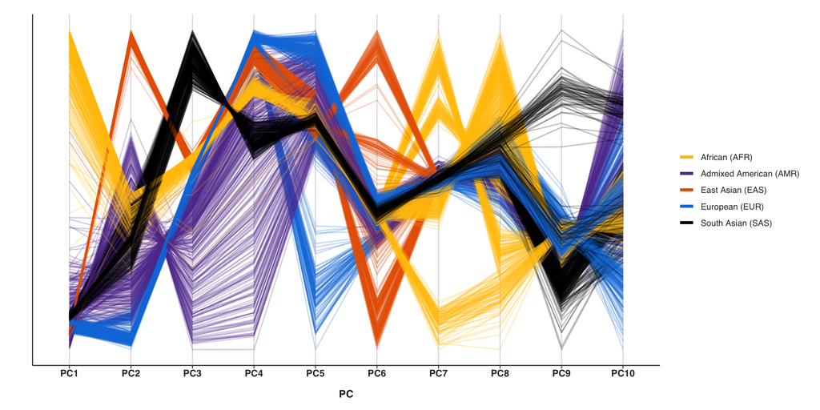

**Figure 1. Parallel coordinates.** 1000 Genomes Sample separation across the first 10 principal components colored by Ancestry.

```r
pc_para <- all_merged[all_merged$SuperPop != "TARGET", c("IID", pc_cols, "SuperPop")]

p_para <- ggparcoord(
    data         = pc_para,
    columns      = which(names(pc_para) %in% pc_cols),
    groupColumn  = "SuperPop",
    scale        = "uniminmax",
    alpha        = 0.25,
    splineFactor = 0
) +
    scale_color_manual(values = super_colors, name = NULL) +
    scale_x_discrete(labels = pc_cols) +
    labs(
        x = "PC", y = ""
    ) +
    theme_pca(
        panel.grid.major.x = element_line(color = "#dddddd", linewidth = 0.5),
        axis.ticks.y       = element_blank(),
        axis.text.y        = element_blank(),
        axis.text.x        = element_text(color = "#333333", size = 10, face = "bold"),
        legend.position    = "right"
    ) +
    guides(color = guide_legend(
        override.aes = list(size = 2.5, alpha = 1, linewidth = 1.5)
    ))


p_para
```

# 4. PCA Scatter Plots

Visualize the principal components to confirm that the reference populations separate as expected, and to see where the TARGET samples project relative to global ancestries.

## 4.1. Set a Function for plotting

```r
# ── Helper function for PCA scatter plots ───────────────────────────────────
make_pca_scatter <- function(df, xpc, ypc, var, title = NULL, subtitle = NULL) {
    ggplot(df, aes(x = .data[[xpc]], y = .data[[ypc]], color = SuperPop, shape = SuperPop)) +
        geom_point(
            data = subset(df, SuperPop != "TARGET"),
            size = 2, alpha = 0.8
        ) +
        geom_point(
            data = subset(df, SuperPop == "TARGET"),
            size = 1.5
        ) +
        scale_color_manual(
            values = super_colors,
            limits = names(super_colors),
            drop = FALSE,
            name = NULL
        ) +
        scale_shape_manual(
            values = c(
                "African (AFR)"          = 16,
                "Admixed American (AMR)" = 16,
                "East Asian (EAS)"       = 16,
                "European (EUR)"         = 16,
                "South Asian (SAS)"      = 16,
                "TARGET"                 = 15
            ),
            limits = names(super_colors),
            drop = FALSE,
            name = NULL,
            guide = "none"
        ) +
        labs(
            title = title,
            subtitle = subtitle,
            x = paste0(xpc, " (", var[xpc], "%)"),
            y = paste0(ypc, " (", var[ypc], "%)")
        ) +
        theme_pca() +
        theme_legend_inset() +
        guides(
            color = guide_legend(nrow = 1, override.aes = list(size = 2.5, alpha = 1))
        ) +
        theme(
            legend.key.size = unit(0.45, "cm")
        )
}
```

## 4.2. Reference PCA

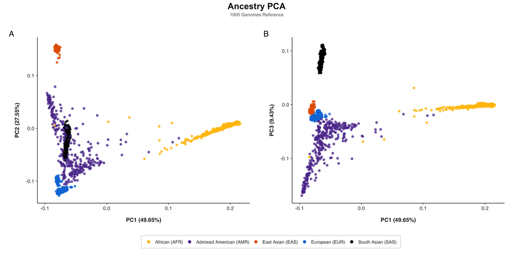

**Figure 2. Reference ancestry PCA.** Projects 1000 Genomes reference samples on PC1 vs PC2 and PC1 vs PC3.

```r
# ── Data subsets ────────────────────────────────────────────────────────────
ref_only <- subset(all_merged, group == "Reference")
ref_plus_target <- all_merged

# ── Reference-only PCA plots ────────────────────────────────────────────────
p_ref_12 <- make_pca_scatter(ref_only, "PC1", "PC2", var)
p_ref_13 <- make_pca_scatter(ref_only, "PC1", "PC3", var)

p_ref_combined <- p_ref_12 + p_ref_13 +
    plot_layout(ncol = 2, guides = "collect") +
    plot_annotation(
        title = "Ancestry PCA",
        subtitle = "1000 Genomes Reference",
        tag_levels = "A",
        theme = theme(
            plot.title = element_text(
                face = "bold", size = 17, color = "#111111",
                hjust = 0.5, margin = margin(b = 4)
            ),
            plot.subtitle = element_text(
                size = 9, color = "#666666",
                hjust = 0.5, margin = margin(b = 10)
            )
        )
    ) &
    theme(
        legend.position = "bottom",
        legend.box.margin = margin(t = 15)
    )

p_ref_combined
```

## 4.3. Reference + TARGET PCA

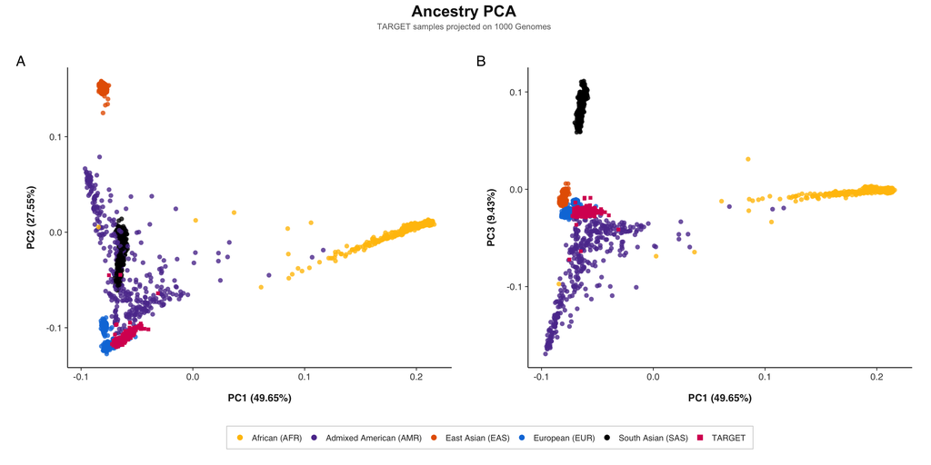

**Figure 3. TARGET ancestry PCA.** Projects TARGET samples onto the 1000 Genomes reference space.

```r
p_target_12 <- make_pca_scatter(ref_plus_target, "PC1", "PC2", var)
p_target_13 <- make_pca_scatter(ref_plus_target, "PC1", "PC3", var)

p_target_combined <- p_target_12 + p_target_13 +
    plot_layout(ncol = 2, guides = "collect") +
    plot_annotation(
        title = "Ancestry PCA",
        subtitle = "TARGET samples projected on 1000 Genomes",
        tag_levels = "A",
        theme = theme(
            plot.title = element_text(
                face = "bold", size = 17, color = "#111111",
                hjust = 0.5, margin = margin(b = 4)
            ),
            plot.subtitle = element_text(
                size = 9, color = "#666666",
                hjust = 0.5, margin = margin(b = 10)
            )
        )
    ) &
    theme(
        legend.position = "bottom",
        legend.box.margin = margin(t = 15)
    )

p_target_combined
```

## 4.4. All 4 Plots Combined

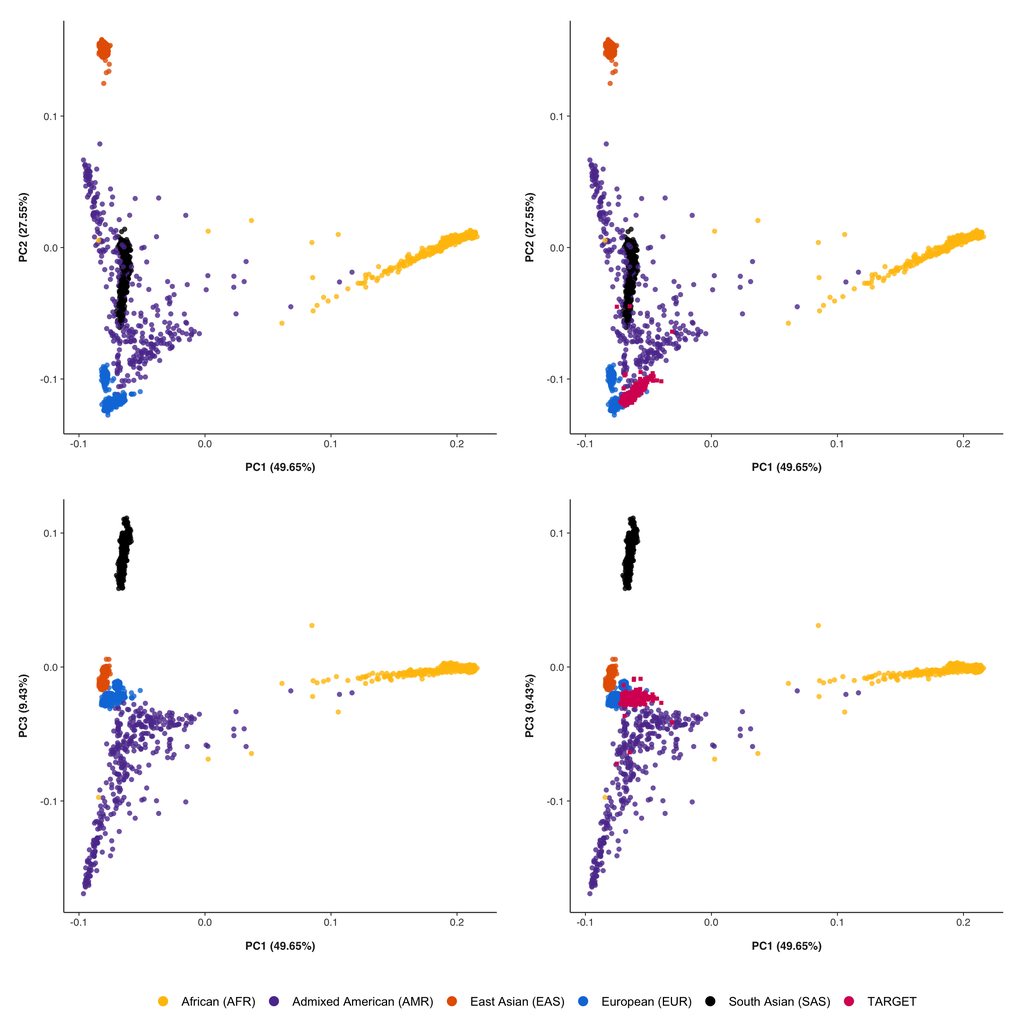

```r
p_all_combined <- (
    (p_ref_12 + theme(legend.position = "none")) +
        (p_target_12 + theme(legend.position = "none"))
) / (
    (p_ref_13 + theme(legend.position = "none")) +
        (p_target_13 + theme(legend.position = "none"))
) +
    plot_layout(guides = "keep") +
    plot_annotation(
        tag_levels = "A",
        theme = theme(
            plot.title = element_text(
                face = "bold", size = 20, color = "#111111",
                hjust = 0.5, margin = margin(b = 4)
            ),
            plot.subtitle = element_text(
                size = 10, color = "#666666",
                hjust = 0.5, margin = margin(b = 10)
            )
        )
    )

legend_df <- data.frame(
    SuperPop = factor(names(super_colors), levels = names(super_colors)),
    x = 1,
    y = 1
)

legend_source <- ggplot(legend_df, aes(x = x, y = y, color = SuperPop)) +
    geom_point(size = 4, alpha = 1) +
    scale_color_manual(values = super_colors, limits = names(super_colors), drop = FALSE, name = NULL) +
    guides(color = guide_legend(nrow = 1, override.aes = list(size = 4, alpha = 1))) +
    theme_void() +
    theme(
        legend.position = "bottom",
        legend.box.margin = margin(t = -1, r = 0, b = 3, l = 0),
        legend.text = element_text(size = 12),
        legend.key.width = unit(0.9, "cm"),
        legend.key.height = unit(0.6, "cm"),
        legend.spacing.x = unit(0.25, "cm"),
        plot.margin = margin(t = 0, r = 0, b = 0, l = 0)
    )

legend_grob <- gtable::gtable_filter(ggplotGrob(legend_source), "guide-box")

p_all_combined <- patchwork::wrap_plots(
    p_all_combined,
    patchwork::wrap_elements(legend_grob),
    ncol = 1,
    heights = c(1, 0.05)
)

p_all_combined
```

# 5. Mahalanobis Outlier Detection

We project TARGET samples onto the 1000 Genomes reference space to provide sufficient variance for ancestry determination and broad clustering. However, downstream analyses like genome-wide association studies (GWAS) require highly homogeneous sample sets and typically adjust for PCA internally, so the Ancestry (EUR, AFR, …) is not as relevant as having similar samples.

We therefore use the TARGET cohort itself to define outlier boundaries (the TARGET-self approach). The size and shape of the study cohort determine the thresholds, ensuring maximum internal homogeneity.

> Note: an alternative EUR-reference approach is documented in *Section 9*.

## 5.1. Why Mahalanobis Distance?

Standard outlier detection (like Mean ± 3 SD) assumes data spreads equally in all directions, forming a perfect circle. However, genetic PCA clusters form ellipses because variance differs along each PC and PCs can be correlated. [Mahalanobis](https://dilipkumar.medium.com/mahalanobis-distance-usage-in-machine-learning-2bd4bcacbcd2) distance measures how many standard deviations a point is away from the center, while accounting for the elliptical shape and directional spread (covariance) of the cluster.

> Note: in R, the `mahalanobis()` function returns the **squared** Mahalanobis distance ($D^2$). Our thresholds and plots strictly use this squared distance.

We compute the squared Mahalanobis distances ($D^2$) using two robust statistical methods:

1. **Minimum Covariance Determinant (MCD)** for the distance calculation.
2. **Tukey’s extreme fence** for the outlier threshold.

## 5.2. Minimum Covariance Determinant

Standard `cov()` and `colMeans()` use every sample in the data. A few extreme points can pull the center and inflate the covariance, making genuine outliers look closer to the bulk than they are. [MCD](https://wis.kuleuven.be/stat/robust/papers/2010/wire-mcd.pdf) avoids this by finding the subset of samples whose covariance matrix has the smallest determinant. The center and covariance are estimated from that clean subset only. Squared Mahalanobis distances ($D^2$) computed from MCD estimates are more sensitive to real outliers because the reference frame is not warped by them.

We use `robustbase::covMcd()` with `alpha = 0.9` (retains the best 90% of samples for estimation). This preserves legitimate substructure while excluding the most extreme 10% of points from the covariance calculation.

> Note: `alpha` can be adjusted based on Sample size and PCA Scatter Inspection.

## 5.3. Tukey’s Extreme Fence

We use Tukey’s extreme fence to set the outlier threshold:

$$\text{Threshold} = Q_3 + k \times \text{IQR}$$

where $Q_1$, $Q_3$ are the 25th/75th percentiles of the squared Mahalanobis distances ($D^2$), $\text{IQR} = Q_3 - Q_1$, and $k$ controls stringency. Tukey’s Fence Method is:

- **Distribution-free**: assumes no specific distribution.
- **Robust**: relies on order statistics (quartiles).
- **Flexible**: adjusts stringency via $k$.

We use $k = 9$ for the TARGET-self approach, which is very conservative and retains internal substructure while only flagging true outliers.

> Note: As $k$ decreases, the fence (i.e., threshold) moves closer to $Q_3$, and more points get labeled as outliers. That makes the rule more stringent.

```r
# ── PCs used for Mahalanobis distance ───────────────────────────────────────
pc_maha <- c("PC1", "PC2")

# ── Tukey fence multipliers ─────────────────────────────────────────────────
# TARGET-self: k = 9 — very conservative, retains substructure and admixture
tukey_k_target <- 9

# ── Data subsets ────────────────────────────────────────────────────────────
target <- subset(all_merged, group == "Projected")
```

## 5.4. TARGET-self Approach

TARGET samples define their own ellipse using MCD-estimated center and covariance. The threshold is set using Tukey’s extreme fence ($Q_3 + 9 \times \text{IQR}$) on the MCD-based squared Mahalanobis distances ($D^2$).

```r
# ── MCD-robust center and covariance for TARGET-self ────────────────────────
target_mcd <- covMcd(target[, pc_maha], alpha = 0.9)
target_center <- target_mcd$center
target_cov <- target_mcd$cov

target$maha_target <- mahalanobis(
    target[, pc_maha],
    center = target_center,
    cov    = target_cov
)

# ── Tukey extreme fence threshold ───────────────────────────────────────────
q1_target <- quantile(target$maha_target, 0.25)
q3_target <- quantile(target$maha_target, 0.75)
iqr_target <- q3_target - q1_target
thresh_target <- as.numeric(q3_target + tukey_k_target * iqr_target)

target$is_outlier_target <- target$maha_target > thresh_target
table(target$is_outlier_target)
```

```
FALSE  TRUE
  843     9
```

## 5.5. Summary

```
── TARGET-self approach ────────────────────────────────────────────────────
  Q1 = 0.73, Q3 = 2.65, IQR = 1.92
  Threshold: Q3 + 9 × IQR = 2.65 + 9 × 1.92 = 19.92
  Outliers:  9 / 852 TARGET samples flagged
```

# 6. Ellipse & Outlier Plot

Draw the calculated Mahalanobis threshold as a strict boundary (ellipse) around the TARGET cluster. Samples falling outside this boundary are flagged as outliers.

```r
# ── Build Mahalanobis ellipse on PC1/PC2 plane ──────────────────────────────
make_maha_ellipse <- function(center, cov_mat, threshold) {
    cov_2d <- cov_mat[c("PC1", "PC2"), c("PC1", "PC2")]
    cov_eig <- eigen(cov_2d)

    axes <- sqrt(cov_eig$values * threshold)
    theta <- seq(0, 2 * pi, length.out = 360)

    ell_pts <- t(cov_eig$vectors %*% (axes * rbind(cos(theta), sin(theta))))

    data.frame(
        PC1 = ell_pts[, 1] + center["PC1"],
        PC2 = ell_pts[, 2] + center["PC2"]
    )
}

ellipse_target <- make_maha_ellipse(target_center, target_cov, thresh_target)
```

```r
# ── Helper function for Mahalanobis PCA plots ───────────────────────────────
make_outlier_plot <- function(target_df, ellipse_df, outlier_col, title = NULL, subtitle = NULL, show_target = TRUE, color_outliers = TRUE) {
    # ── Unified legend levels, colors, and shapes ───────────────────────────
    all_levels <- c(
        "African (AFR)", "Admixed American (AMR)", "East Asian (EAS)",
        "European (EUR)", "South Asian (SAS)",
        "TARGET", "TARGET Pass", "TARGET Outlier"
    )

    outlier_colors <- c(
        "African (AFR)"          = "#FFC107",
        "Admixed American (AMR)" = "#5D3A9B",
        "East Asian (EAS)"       = "#E66100",
        "European (EUR)"         = "#0C7BDC",
        "South Asian (SAS)"      = "#000000",
        "TARGET"                 = "#D81B60",
        "TARGET Pass"            = "#40B0A6",
        "TARGET Outlier"         = "#D41159"
    )

    outlier_shapes <- c(
        "African (AFR)"          = 16,
        "Admixed American (AMR)" = 16,
        "East Asian (EAS)"       = 16,
        "European (EUR)"         = 16,
        "South Asian (SAS)"      = 16,
        "TARGET"                 = 15,
        "TARGET Pass"            = 15,
        "TARGET Outlier"         = 17
    )

    # ── Reference data with legend_label column ─────────────────────────────
    ref_data <- subset(all_merged, group == "Reference")
    ref_data$legend_label <- factor(as.character(ref_data$SuperPop), levels = all_levels)

    # ── Invisible dummy points for ALL levels (ensures identical guides) ────
    dummy <- data.frame(
        PC1 = rep(NA_real_, length(all_levels)),
        PC2 = rep(NA_real_, length(all_levels)),
        legend_label = factor(all_levels, levels = all_levels)
    )

    p <- ggplot() +
        geom_point(
            data = dummy,
            aes(x = PC1, y = PC2, color = legend_label, shape = legend_label),
            na.rm = TRUE
        ) +
        geom_point(
            data = ref_data,
            aes(x = PC1, y = PC2, color = legend_label, shape = legend_label),
            size = 2, alpha = 0.75
        ) +
        geom_polygon(
            data = ellipse_df,
            aes(x = PC1, y = PC2),
            fill = "#D41159", color = "#1E1E2E",
            alpha = 0.10, linewidth = 0.7
        )

    if (show_target) {
        if (color_outliers) {
            pass_df <- target_df[!target_df[[outlier_col]], ]
            pass_df$legend_label <- factor("TARGET Pass", levels = all_levels)
            out_df <- target_df[target_df[[outlier_col]], ]
            out_df$legend_label <- factor("TARGET Outlier", levels = all_levels)

            p <- p +
                geom_point(
                    data = pass_df,
                    aes(x = PC1, y = PC2, color = legend_label, shape = legend_label),
                    size = 1.5
                ) +
                geom_point(
                    data = out_df,
                    aes(x = PC1, y = PC2, color = legend_label, shape = legend_label),
                    size = 1.8
                )
        } else {
            tgt_df <- target_df
            tgt_df$legend_label <- factor("TARGET", levels = all_levels)

            p <- p +
                geom_point(
                    data = tgt_df,
                    aes(x = PC1, y = PC2, color = legend_label, shape = legend_label),
                    size = 1.5
                )
        }
    }

    p +
        scale_color_manual(values = outlier_colors, drop = FALSE, name = NULL) +
        scale_shape_manual(values = outlier_shapes, drop = FALSE, name = NULL) +
        labs(
            title = title,
            subtitle = subtitle,
            x = paste0("PC1 (", var["PC1"], "%)"),
            y = paste0("PC2 (", var["PC2"], "%)")
        ) +
        theme_pca() +
        theme_legend_inset() +
        guides(
            color = guide_legend(nrow = 1, override.aes = list(size = 2.5, alpha = 1)),
            shape = guide_legend(nrow = 1, override.aes = list(size = 2.5, alpha = 1))
        )
}
```

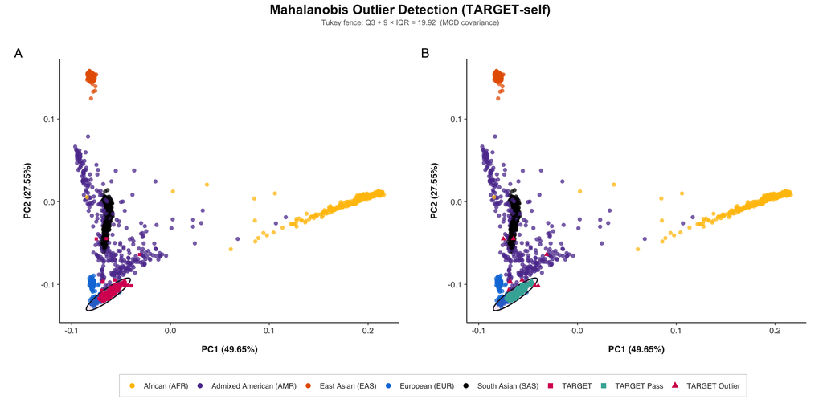

**Figure 5. TARGET-self outliers.** Identifies outliers based on the TARGET cohort covariance ellipse.

```r
p_out_target_all <- make_outlier_plot(
    target_df = target,
    ellipse_df = ellipse_target,
    outlier_col = "is_outlier_target",
    show_target = TRUE,
    color_outliers = FALSE
)

p_out_target <- make_outlier_plot(
    target_df = target,
    ellipse_df = ellipse_target,
    outlier_col = "is_outlier_target",
    show_target = TRUE,
    color_outliers = TRUE
)

p_out_target_combined <-
    (p_out_target_all + theme(legend.position = "none")) +
    p_out_target +
    plot_layout(ncol = 2, guides = "collect") +
    plot_annotation(
        title = "Mahalanobis Outlier Detection (TARGET-self)",
        subtitle = sprintf("Tukey fence: Q3 + %d \u00d7 IQR = %.2f  (MCD covariance)", tukey_k_target, thresh_target),
        tag_levels = "A",
        theme = theme(
            plot.title = element_text(
                face = "bold", size = 16, color = "#111111",
                hjust = 0.5, margin = margin(b = 4)
            ),
            plot.subtitle = element_text(
                size = 9, color = "#666666",
                hjust = 0.5, margin = margin(b = 10)
            ),
            legend.position = "bottom",
            legend.box.margin = margin(t = 15)
        )
    )

p_out_target_combined
```

# 7. Mahalanobis Lollipop Plot

Visualize the distance of every individual sample from the cluster center. The dashed line marks Tukey’s Fence threshold. Samples above the line are flagged as outliers.

```r
# ── Helper function: ranked Mahalanobis distance lollipop plot ──────────────
make_lollipop_plot <- function(df, distance_col, outlier_col, threshold,
                               thresh_label, title = NULL, subtitle = NULL) {
    # Order samples by Mahalanobis distance
    df_ordered <- df[order(df[[distance_col]]), ]
    df_ordered$sample_rank <- seq_len(nrow(df_ordered))

    # Create clean labels for plotting
    df_ordered$outlier_status <- factor(
        ifelse(df_ordered[[outlier_col]], "Outlier", "Pass"),
        levels = c("Pass", "Outlier")
    )

    # Avoid drawing from zero on a log10 axis
    min_positive <- min(df_ordered[[distance_col]][df_ordered[[distance_col]] > 0], na.rm = TRUE)
    y_start <- min_positive / 2
    y_label <- 10^(log10(threshold) - 0.18)

    ggplot(
        df_ordered,
        aes(x = sample_rank, y = .data[[distance_col]], color = outlier_status)
    ) +
        annotate(
            "rect",
            xmin = -Inf, xmax = Inf,
            ymin = threshold, ymax = Inf,
            fill = "#D41159", alpha = 0.04
        ) +
        annotate(
            "rect",
            xmin = -Inf, xmax = Inf,
            ymin = y_start, ymax = threshold,
            fill = "#40B0A6", alpha = 0.04
        ) +
        geom_hline(
            yintercept = threshold,
            color = "#D41159",
            linetype = "dashed",
            linewidth = 0.9
        ) +
        geom_segment(
            aes(xend = sample_rank, y = y_start, yend = .data[[distance_col]]),
            linewidth = 0.3,
            alpha = 0.5
        ) +
        geom_point(size = 1.8, alpha = 0.85) +
        annotate(
            "text",
            x = -Inf,
            y = y_label,
            label = thresh_label,
            color = "#CC0000",
            hjust = -0.03,
            vjust = 0.5,
            size = 3
        ) +
        scale_x_continuous(expand = expansion(mult = c(0.04, 0.02))) +
        scale_y_log10(
            breaks = c(1, 5, round(threshold, 1), 50, 100, 500, 1000, 5000),
            labels = function(x) round(x, 1)
        ) +
        scale_color_manual(
            values = c("Pass" = "#40B0A6", "Outlier" = "#D41159"),
            labels = c(
                "Pass"    = sprintf("Pass (n=%d)", sum(!df[[outlier_col]])),
                "Outlier" = sprintf("Outlier (n=%d)", sum(df[[outlier_col]]))
            ),
            name = NULL
        ) +
        labs(
            title = title,
            subtitle = subtitle,
            x = "Samples ranked by Mahalanobis distance",
            y = "Mahalanobis distance\u00b2 (log10)"
        ) +
        theme_pca(
            panel.grid.major.y = element_line(color = "#eeeeee", linewidth = 0.4),
            axis.ticks.x = element_blank(),
            axis.text.x = element_blank(),
            legend.position = c(0.02, 0.97),
            legend.justification = c("left", "top"),
            legend.background = element_rect(
                fill = alpha("white", 0.85),
                color = "#cccccc",
                linewidth = 0.35
            ),
            legend.margin = margin(6, 8, 6, 8)
        ) +
        theme(plot.margin = margin(15, 15, 12, 22)) +
        coord_cartesian(clip = "off")
}
```

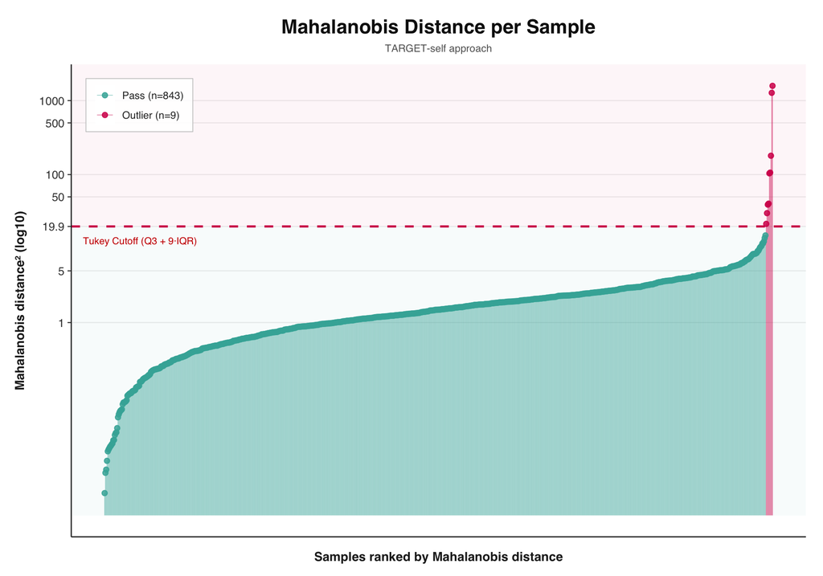

**Figure 6. TARGET-self distances.** Ranks TARGET samples by Mahalanobis distance to identify outliers.

```r
# ── TARGET-self lollipop plot ──────────────────────────────────────────────
lollipop_target <- make_lollipop_plot(
    df           = target,
    distance_col = "maha_target",
    outlier_col  = "is_outlier_target",
    threshold    = thresh_target,
    thresh_label = sprintf("Tukey Cutoff (Q3 + %d·IQR)", tukey_k_target),
    title        = "Mahalanobis Distance per Sample",
    subtitle     = "TARGET-self approach"
)

lollipop_target
```

# 8. Export Outliers

Write the IDs of the identified outlier samples to a plain text file. This file is used in downstream pipeline steps to exclude these samples from the final dataset.

> Note: The outliers file is adapted for *PLINK* sample removal with *FID* and *IID* columns.

```r
# ── Samples excluded using TARGET-self Mahalanobis approach ─────────────
outliers_target_self <- subset(target, is_outlier_target)[, c("FID", "IID")]

write.table(
    outliers_target_self,
    "samples-by-pca-target.txt",
    col.names = FALSE,
    row.names = FALSE,
    quote = FALSE,
    sep = "\t"
)

cat(sprintf(
    "TARGET-self: %d outliers written to samples-by-pca-target.txt\n",
    nrow(outliers_target_self)
))
```

```
TARGET-self: 9 outliers written to samples-by-pca-target.txt
```

# 9. Alternative Approach: EUR-Reference

An alternative approach is to use the 1000 Genomes European (or Ancestry of choice) cluster to define outlier boundaries. A TARGET sample is excluded if its MCD-based squared Mahalanobis distance ($D^2$) from the EUR reference cluster exceeds Tukey’s fence.

> Note: This is documented for Ancestry reproducibility, though the primary and recommended approach uses the TARGET cohort directly for downstream homogeneity.

```r
# ── Tukey fence multiplier for EUR ──────────────────────────────────────────
# k = 3 — flags samples clearly outside the European cluster
tukey_k_eur <- 3

# ── Data subset for EUR reference ───────────────────────────────────────────
ref_eur <- subset(all_merged, group == "Reference" & SuperPop == "European (EUR)")
```

```r
# ── MCD-robust center and covariance for EUR reference ──────────────────────
eur_mcd <- covMcd(ref_eur[, pc_maha], alpha = 0.9)
eur_center <- eur_mcd$center
eur_cov <- eur_mcd$cov

# Mahalanobis distances for EUR reference samples
ref_eur$maha_ref_eur <- mahalanobis(
    ref_eur[, pc_maha],
    center = eur_center,
    cov    = eur_cov
)

# Mahalanobis distances for TARGET samples relative to EUR reference
target$maha_ref_eur <- mahalanobis(
    target[, pc_maha],
    center = eur_center,
    cov    = eur_cov
)

# ── Tukey fence threshold on EUR-reference distances ────────────────────────
q1_eur <- quantile(target$maha_ref_eur, 0.25)
q3_eur <- quantile(target$maha_ref_eur, 0.75)
iqr_eur <- q3_eur - q1_eur
thresh_eur <- as.numeric(q3_eur + tukey_k_eur * iqr_eur)

target$is_outlier_ref_eur <- target$maha_ref_eur > thresh_eur
```

## 9.1. EUR-Reference Summary

```
── EUR-reference approach ──────────────────────────────────────────────────
  Q1 = 2.00, Q3 = 11.61, IQR = 9.61
  Threshold: Q3 + 3 × IQR = 11.61 + 3 × 9.61 = 40.45
  Outliers:  9 / 852 TARGET samples flagged
```

## 9.2. EUR-Reference Ellipse Plots

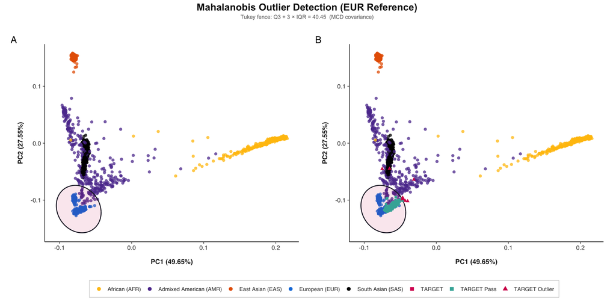

**Figure 8. EUR-reference outliers.** Identifies TARGET outliers based on the European reference covariance ellipse.

```r
ellipse_ref_eur <- make_maha_ellipse(eur_center, eur_cov, thresh_eur)

p_out_ref_eur_no_target <- make_outlier_plot(
    target_df   = target,
    ellipse_df  = ellipse_ref_eur,
    outlier_col = "is_outlier_ref_eur",
    show_target = FALSE
)

p_out_ref_eur <- make_outlier_plot(
    target_df   = target,
    ellipse_df  = ellipse_ref_eur,
    outlier_col = "is_outlier_ref_eur"
)

p_out_eur_combined <-
    (p_out_ref_eur_no_target + theme(legend.position = "none")) +
    p_out_ref_eur +
    plot_layout(ncol = 2, guides = "collect") +
    plot_annotation(
        title = "Mahalanobis Outlier Detection (EUR Reference)",
        subtitle = sprintf("Tukey fence: Q3 + %d \u00d7 IQR = %.2f  (MCD covariance)", tukey_k_eur, thresh_eur),
        tag_levels = "A",
        theme = theme(
            plot.title = element_text(
                face = "bold", size = 16, color = "#111111",
                hjust = 0.5, margin = margin(b = 4)
            ),
            plot.subtitle = element_text(
                size = 9, color = "#666666",
                hjust = 0.5, margin = margin(b = 10)
            ),
            legend.position = "bottom",
            legend.box.margin = margin(t = 15)
        )
    )

p_out_eur_combined
```

## 9.3. EUR-Reference Lollipop Plot

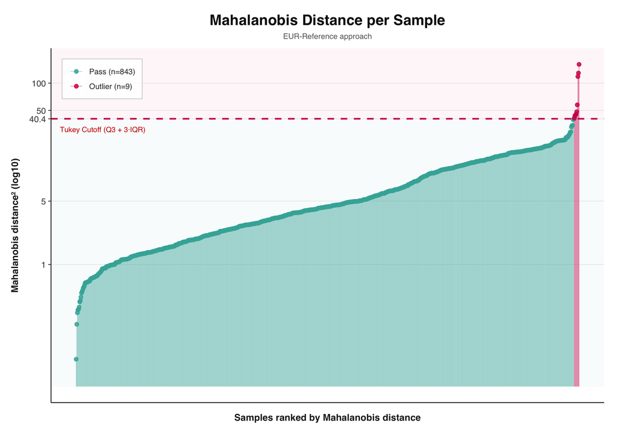

**Figure 9. EUR-reference distances.** Ranks TARGET samples by Mahalanobis distance to the European reference.

```r
lollipop_ref_eur <- make_lollipop_plot(
    df           = target,
    distance_col = "maha_ref_eur",
    outlier_col  = "is_outlier_ref_eur",
    threshold    = thresh_eur,
    thresh_label = sprintf("Tukey Cutoff (Q3 + %d·IQR)", tukey_k_eur),
    title        = "Mahalanobis Distance per Sample",
    subtitle     = "EUR-Reference approach"
)

lollipop_ref_eur
```

## 9.4. Export EUR-Reference Outliers

```r
outliers_ref_eur <- subset(target, is_outlier_ref_eur)[, c("FID", "IID")]

write.table(
    outliers_ref_eur,
    "samples-by-pca-eur.txt",
    col.names = FALSE,
    row.names = FALSE,
    quote = FALSE,
    sep = "\t"
)

cat(sprintf(
    "EUR-reference: %d outliers written to samples-by-pca-eur.txt\n",
    nrow(outliers_ref_eur)
))
```

```
EUR-reference: 9 outliers written to samples-by-pca-eur.txt
```

# Future Work

I am currently developing a *Shiny app* to automate the entire PCA and outlier detection pipeline, from just your `plink` or `vcf` genotype data.

*Thanks for Reading this far, Stay tuned: github.com/BioInUmer !*